# act_report

## WeRateDogs Data Wrangling

### Overview

This project provides focuses on wrangling of the ratings of dogs from a Twitter handle WeRateDogs. In the development of the project, the Gather-Assess-Clean approach was adopted for the wrangling process. This twitter account consists of pictures of various dogs and their ratings. The datasets used include 'image predictions', 'twitter_archive', 'tweet_json. Each datasets was cleaned and merged to get a master dataset. Upon completion of wrangling the master dataset was analyzed and visualized to share some useful insights.

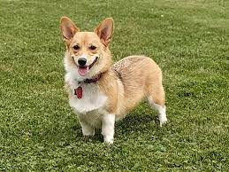

### Gathering

Image prediction This file (image_predictions.tsv) is present in each tweet according to a neural network. It is hosted on Udacity's servers and was downloaded programmatically using the Requests library and the following URL: https://d17h27t6h515a5.cloudfront.net/topher/2017/August/599fd2ad_image-predictions/image-predictions.tsv

Twitter archive It contains basic information about 2356 tweets and was downloaded manually

Tweet_json Using the tweet IDs in the WeRateDogs Twitter archive, Twitter API was queried for each tweet's JSON data using Python's Tweepy library and stored each tweet's entire set of JSON data in a file called tweet_json.txt file.

### Assess

After gathering all three pieces of data, each of them was assesed visually and progammatically for quality and tidiness issues

Assessment

1. Visual assessment: each piece of gathered data is displayed in the Jupyter Notebook for visual assessment purposes.
2. Programmatic assessment: pandas' functions and/or methods are used to assess the data.

###### Quality issues

Twitter_archive

1. tweet_id is string not integer
2. rating_numerator and rating_denominator have extreme values
3. Erroneous data type (timestamp column is string instead of datetime)
4. 'in_reply_to_status_id', 'in_reply_to_user_id,'retweeted_status_id', 'retweeted_status_user_id','retweeted_status_timestamp' have so many null values

Image_prediction

1. tweet_id is string not integer

Tweet_json

1. tweet_id should be string not integer

###### Tidiness issues

Twitter_archive

1. doggo, floofer, pupper, and puppo are dog stages hence should be shrinked into a column
2. drop columns not relevant for analysis especially because they contain so many null values

Image_prediction

1. drop columns not relevant for analysis

Tweet_json

1. followers_count have 66 unique values and friend_count have 1 unique value (somethings wrong!!!)

### Clean

All were issues documentated while assessing were cleaned.

Cleaning procedure

- A copy of the original data was made.
- The define-code-test framework was used and clearly documented for each datasets
- The cleaning includes merging individual pieces of data resulting in a high-quality master pandas Dataframe.

### Analysis and Visualization

Upon completion of the wrangling, the following questions were posed;

- Breed of dog with the highest rating
- Most popular breed of dod (dog count)
- Most common dog stage
- Retweet count and favorite count can be attributed to the popularity of an account(tweet_id), hence we attribute tweet id's with high total retweet_count and favorite_count to users with high followers

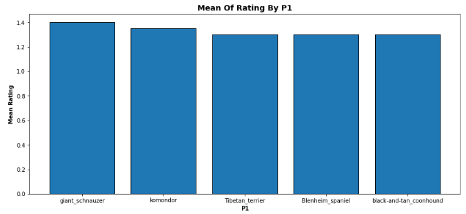

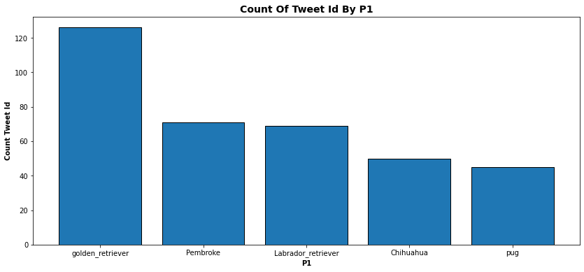

multiple insights were gotten from the analysis and visualization, which includes;

###### Insights

- Golden retriever is the most popular dog with atleast 50% certainty
- Averagely Giant schnauzer has the higest rating
- Pupper is the most common dog stage
- The correlation between retweet and favorite is positive which implies the higher the likes on a Twitter post, the higher the the retweets.
- With atleast 50% certainty of the dog breed, of the top 20 users; Golden retriever, Chihuahua, Pembroke are the common dog breed